# Generalized Linear Models

## LASSO

How should we decide which predictors to include? Add a penalty to the optimization criterion. Instead of just minimizing the sum of squared residuals, also add in an amount proportional to the square or absolute value of the coefficients. If a parameter does not “help” your predictions, the best solution will be to make that coefficient zero, or close to it. For this to make sense, each predictor should have the same standard deviation (usually 1) unless you want *a priori* to make one predictor more or less important than another.

LASSO does variable selection; Ridge regression simply makes some parameters small.

The formula interface is not available for glmnet (but see the package `glmnetUtils`.)

```r
diatom_environment_ss <- diatom_environment |>
  filter(ScientificName_accepted == "Leptocylindrus danicus") |>
  filter(!(is.na(NO3_NO2_USF + PO4_USF + SiO4_USF + Temperature +
                   Salinity_bottles + pH + depth + Month_local)))
# y <- diatom_environment_ss |> pull(present)
y <- diatom_environment_ss$present # same thing
x <- diatom_environment_ss |> select(NO3_NO2_USF, PO4_USF, SiO4_USF, Temperature,
                                     Salinity_bottles,  pH, depth, Month_local) |>
  as.matrix() |> scale()
set.seed(1)
model3 <- cv.glmnet(x, y, family = "binomial", alpha = 1)
model3
```

```
##
## Call:  cv.glmnet(x = x, y = y, family = "binomial", alpha = 1)
##
## Measure: Binomial Deviance
##
##      Lambda Index Measure      SE Nonzero
## min 0.01870    21  0.9072 0.05152       4
## 1se 0.08284     5  0.9561 0.05754       1
```

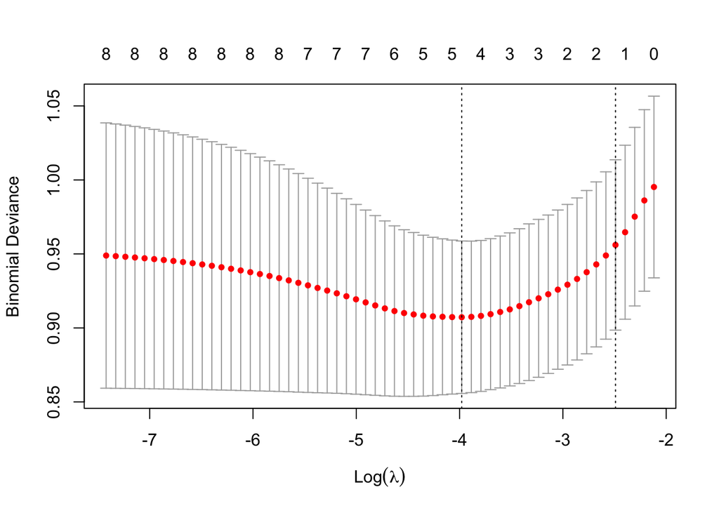

```r
plot(model3)
```

```r
model4 <- glmnet(x, y, family = "binomial", lambda = model3$lambda.min, alpha = 1)
model4
```

```
##
## Call:  glmnet(x = x, y = y, family = "binomial", alpha = 1, lambda = model3$lambda.min)
##
##   Df  %Dev Lambda
## 1  4 10.83 0.0187
```

```r
tidy(model4) # also # coef(model4)
```

```
## # A tibble: 5 × 5
##   term         step estimate lambda dev.ratio
##   <chr>       <dbl>    <dbl>  <dbl>     <dbl>
## 1 (Intercept)     1  -1.55   0.0187     0.108
## 2 PO4_USF         1   0.112  0.0187     0.108
## 3 Temperature     1  -0.518  0.0187     0.108
## 4 depth           1  -0.0574 0.0187     0.108
## 5 Month_local     1  -0.211  0.0187     0.108
```

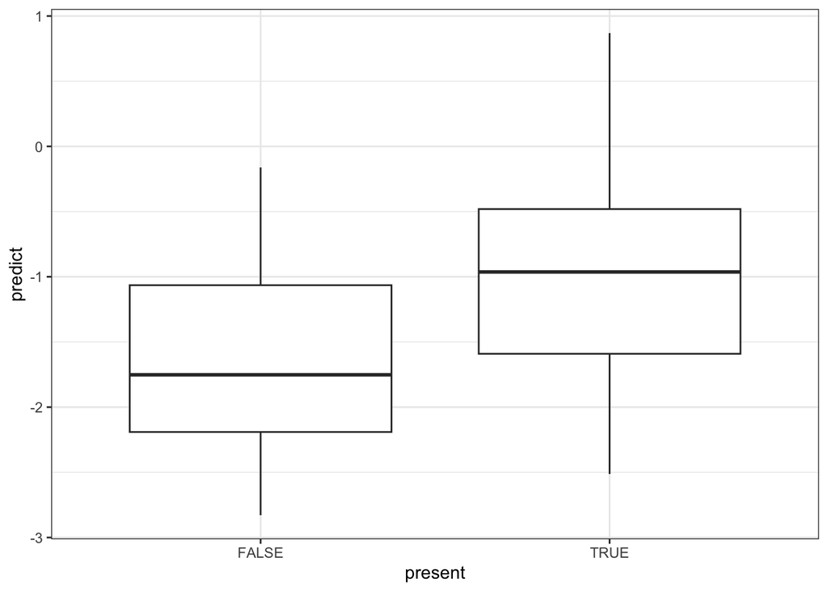

```r
diatom_environment_ss |>
  mutate(predict = as.vector(predict(model4, newx = x))) |>
  ggplot(aes(present, predict)) +
  geom_boxplot() +
  theme_bw()
```

Confusion matrix

```r
diatom_environment_ss |>
  mutate(predict = as.vector(predict(model4, newx = x))) |>
  count(present, exp(predict) > 0.5)
```

```
## # A tibble: 4 × 3
##   present `exp(predict) > 0.5`     n
##   <lgl>   <lgl>                <int>
## 1 FALSE   FALSE                  255
## 2 FALSE   TRUE                    15
## 3 TRUE    FALSE                   44
## 4 TRUE    TRUE                    22
```

```r
diatom_sum_environment_ss <- diatom_sum_environment |>
  filter(!(is.na(NO3_NO2_USF + PO4_USF + SiO4_USF + Temperature + Salinity_bottles +
                   pH + depth + Month_local)),
         abundance > 0)
y <- diatom_sum_environment_ss$log_abundance
x <- diatom_sum_environment_ss |> select(NO3_NO2_USF, PO4_USF, SiO4_USF, Temperature,
                                         Salinity_bottles, pH, depth, Month_local) |>
  as.matrix() |> scale()
set.seed(1)
model5 <- cv.glmnet(x, y, family = "gaussian", alpha = 1.0)
model5
```

```
##
## Call:  cv.glmnet(x = x, y = y, family = "gaussian", alpha = 1)
##
## Measure: Mean-Squared Error
##
##     Lambda Index Measure     SE Nonzero
## min 0.0097    58   6.332 0.6087       8
## 1se 0.3639    19   6.863 0.2488       2
```

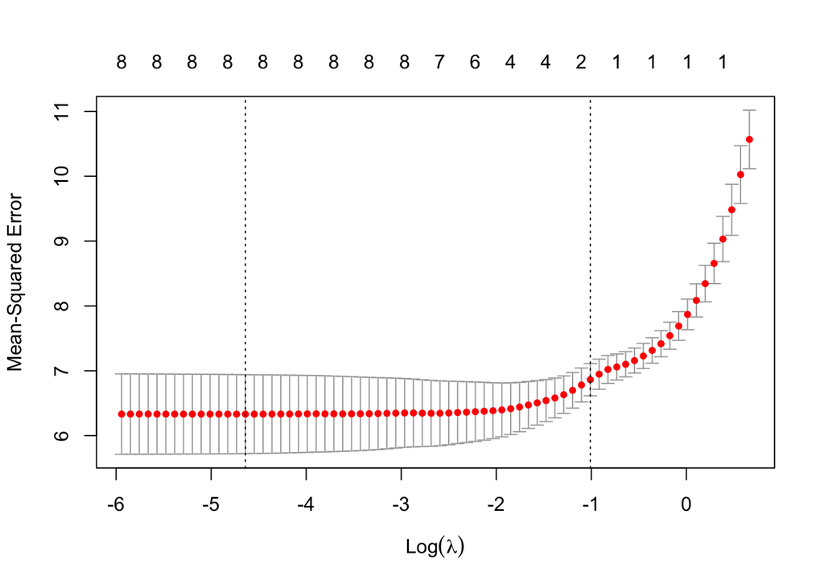

```r
plot(model5)
```

```r
model6 <- glmnet(x, y, family = "gaussian", lambda = model5$lambda.min, alpha = 1.0)
model6
```

```
##
## Call:  glmnet(x = x, y = y, family = "gaussian", alpha = 1, lambda = model5$lambda.min)
##
##   Df  %Dev   Lambda
## 1  8 44.49 0.009664
```

```r
tidy(model6) # also # coef(model6)
```

```
## # A tibble: 9 × 5
##   term              step estimate  lambda dev.ratio
##   <chr>            <dbl>    <dbl>   <dbl>     <dbl>
## 1 (Intercept)          1    0.474 0.00966     0.445
## 2 NO3_NO2_USF          1   -0.564 0.00966     0.445
## 3 PO4_USF              1    0.614 0.00966     0.445
## 4 SiO4_USF             1   -0.182 0.00966     0.445
## 5 Temperature          1   -2.36  0.00966     0.445
## 6 Salinity_bottles     1    0.175 0.00966     0.445
## 7 pH                   1    0.906 0.00966     0.445
## 8 depth                1   -0.260 0.00966     0.445
## 9 Month_local          1    0.186 0.00966     0.445
```

## Plots

Show predicted log abundance vs observed.

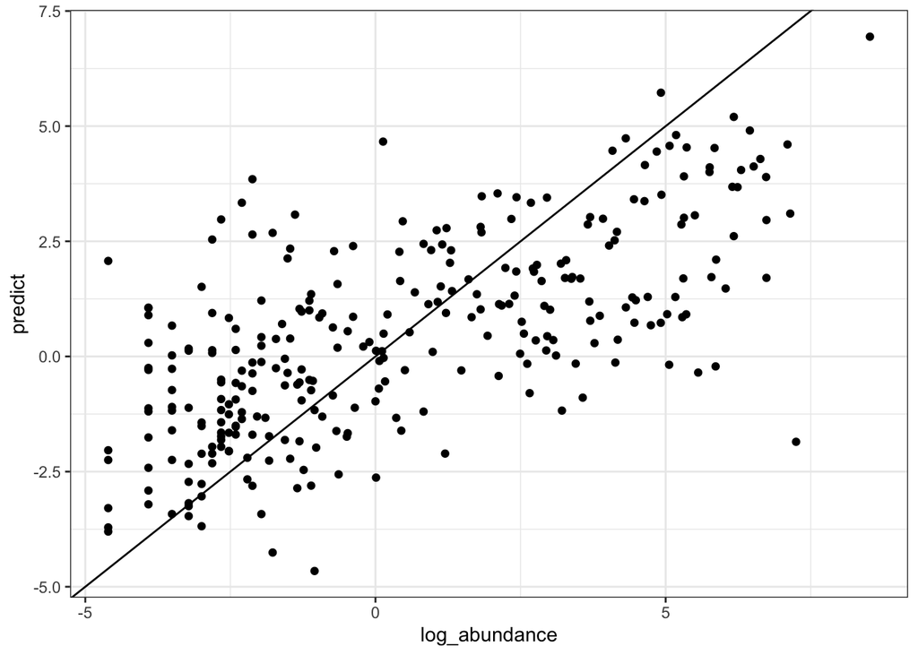

```r
diatom_sum_environment_ss |>
  mutate(predict = as.vector(predict(model6, newx = x, type = "response"))) |>
  ggplot(aes(log_abundance, predict)) +
  geom_point() +
  geom_abline(intercept = 0, slope = 1) +
  theme_bw()
```

Show residuals vs predictions.

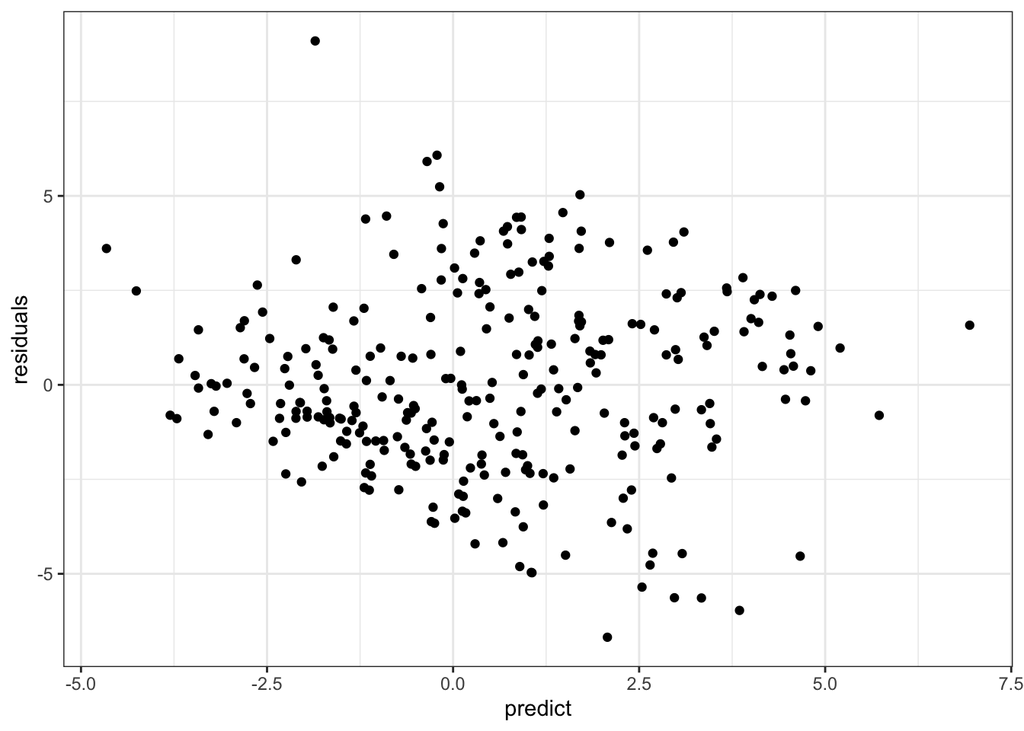

```r
diatom_sum_environment_ss |>
  mutate(predict = as.vector(predict(model6, newx = x)),
         residuals = log_abundance - predict) |>
  ggplot(aes(predict, residuals)) +
  geom_point() +
  theme_bw()
```

Are the residuals Normally distributed?

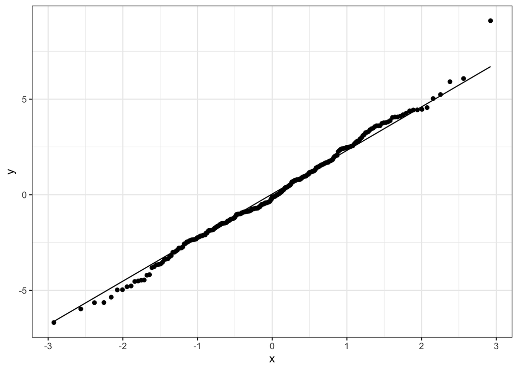

```r
diatom_sum_environment_ss |>
  mutate(predict = as.vector(predict(model6, newx = x)),
         residuals = log_abundance - predict) |>
  ggplot(aes(sample = residuals)) +
  stat_qq() + stat_qq_line() +
  theme_bw()
```